# Cleaning the Data

## We define variables we want to use to predict high or low values as our x and our high or low values as our y

```python
X = np.asarray(logreg[["do_mg_l", "water_temp_cel_s", 'p_h']])
X[0:5]
```

```
array([[ 8.75, 28.83,  8.84],
       [ 7.27, 25.21,  9.13],
       [ 8.55, 25.1 ,  8.42],
       [ 9.3 , 28.77,  8.53],
       [13.83, 22.4 ,  9.14]])
```

```python
y = np.asarray(logreg['high'])
y [0:5]
```

```
array([0, 0, 0, 0, 0])
```

## Normalizing the dataset helps ensure we are working with data that has a bell shaped curve

```python
from sklearn import preprocessing
X = preprocessing.StandardScaler().fit(X).transform(X)
X[0:5]
```

```
array([[ 0.04828534,  1.35383039,  0.38307725],
       [-0.9430324 , -0.02062406,  0.91432313],
       [-0.08567651, -0.06238925, -0.38631334],
       [ 0.41668045,  1.33104938, -0.18480628],
       [ 3.45091652, -1.08753483,  0.93264195]])
```

## Logistic regression uses the technique of "supervised learning". We split our dataset into a train and test set.

```python
from sklearn.model_selection import train_test_split
X_train, X_test, y_train, y_test = train_test_split( X, y, test_size=0.2, random_state=4)
print ('Train set:', X_train.shape,  y_train.shape)
print ('Test set:', X_test.shape,  y_test.shape)
```

```
Train set: (616, 3) (616,)
Test set: (155, 3) (155,)
```

```python
from sklearn.linear_model import LogisticRegression
from sklearn.metrics import confusion_matrix
LR = LogisticRegression(C=0.01, solver='liblinear').fit(X_train,y_train)
LR
```

```
LogisticRegression(C=0.01, solver='liblinear')
```

```python
yhat = LR.predict(X_test)
yhat
```

```
array([0, 0, 0, 0, 0, 0, 0, 0, 0, 0, 0, 0, 0, 0, 0, 0, 0, 0, 0, 0, 0, 0,
       0, 0, 0, 0, 0, 0, 0, 0, 0, 0, 0, 0, 0, 0, 0, 0, 0, 0, 0, 0, 0, 0,
       0, 0, 0, 0, 0, 0, 0, 0, 0, 0, 0, 0, 0, 0, 0, 0, 0, 0, 0, 0, 0, 0,
       0, 0, 0, 0, 0, 0, 0, 0, 0, 0, 0, 0, 0, 0, 0, 0, 0, 0, 0, 0, 0, 0,
       0, 0, 0, 0, 0, 0, 0, 0, 0, 0, 0, 0, 0, 0, 0, 0, 0, 0, 0, 0, 0, 0,
       0, 0, 0, 0, 0, 0, 0, 0, 0, 0, 0, 0, 0, 0, 0, 0, 0, 0, 0, 0, 0, 0,
       0, 0, 0, 0, 0, 0, 0, 0, 0, 0, 0, 0, 0, 0, 0, 0, 0, 0, 0, 0, 0, 0,
       0])
```

```python
yhat_prob = LR.predict_proba(X_test)
yhat_prob[0:5]
```

```
array([[0.73036075, 0.26963925],
       [0.71859072, 0.28140928],
       [0.71988206, 0.28011794],
       [0.73444339, 0.26555661],
       [0.73669866, 0.26330134]])
```

#### Let's try the jaccard index for accuracy evaluation. we can define jaccard as the size of the intersection divided by the size of the union of the two label sets. If the entire set of predicted labels for a sample strictly matches with the true set of labels, then the subset accuracy is 1.0; otherwise it is 0.0.

```python
from sklearn.metrics import jaccard_score
jaccard_score(y_test, yhat,pos_label=0)
```

```
0.8709677419354839
```

```python
from sklearn.metrics import classification_report, confusion_matrix
import itertools
def plot_confusion_matrix(cm, classes,
                          normalize=False,
                          title='Confusion matrix',
                          cmap=plt.cm.Blues):
    """
    This function prints and plots the confusion matrix.
    Normalization can be applied by setting `normalize=True`.
    """
    if normalize:
        cm = cm.astype('float') / cm.sum(axis=1)[:, np.newaxis]
        print("Normalized confusion matrix")
    else:
        print('Confusion matrix, without normalization')

    print(cm)

    plt.imshow(cm, interpolation='nearest', cmap=cmap)
    plt.title(title)
    plt.colorbar()
    tick_marks = np.arange(len(classes))
    plt.xticks(tick_marks, classes, rotation=45)
    plt.yticks(tick_marks, classes)

    fmt = '.2f' if normalize else 'd'
    thresh = cm.max() / 2.
    for i, j in itertools.product(range(cm.shape[0]), range(cm.shape[1])):
        plt.text(j, i, format(cm[i, j], fmt),
                 horizontalalignment="center",
                 color="white" if cm[i, j] > thresh else "black")

    plt.tight_layout()
    plt.ylabel('True label')
    plt.xlabel('Predicted label')
print(confusion_matrix(y_test, yhat, labels=[1,0]))
```

```
[[  0  20]
 [  0 135]]
```

```
Confusion matrix, without normalization
[[  0  20]
 [  0 135]]
```

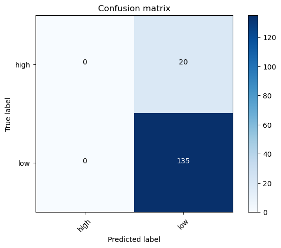

```python
cnf_matrix = confusion_matrix(y_test, yhat, labels=[1,0])
np.set_printoptions(precision=2)
plt.figure()
plot_confusion_matrix(cnf_matrix, classes=['high','low'],normalize= False,  title='Confusion matrix')
```

```python
print (classification_report(y_test, yhat))
```

```
              precision    recall  f1-score   support

           0       0.87      1.00      0.93       135
           1       0.00      0.00      0.00        20

    accuracy                           0.87       155
   macro avg       0.44      0.50      0.47       155
weighted avg       0.76      0.87      0.81       155
```

# We also tried with different values of microcystin being considered high and did not receive good results

# Overall, I wasn't able to find a good model to fit the data and predict Microcystin

## While I didn't receive the results I wanted, I gained experience working with a real life dataset. Often times data will not be easy to work with

## I learned new techniques to apply elsewhere and gained knowledge on what techniques to try first and which probably will not work

## As someone who has spent months working with the data, we gave suggestions to Lakes and Streams to improve results

## The most important is gathering data more frequently, so there aren't as many big gaps in the data

# I look forward to using the knowledge I've learned in Python, Pandas, and Machine Learning to help a company in the future. Hopefully with easier to work with data